# Project description

AllLife Bank wants to focus on its credit card customer base in the next financial year. They have been advised by their marketing research team, that the penetration in the market can be improved. Based on this input, the Marketing team proposes to run personalized campaigns to target new customers as well as upsell to existing customers. Another insight from the market research was that the customers perceive the support services of the back poorly. Based on this, the Operations team wants to upgrade the service delivery model, to ensure that customer queries are resolved faster.

### Objective

To identify different segments in the existing customer, based on their spending patterns as well as past interaction with the bank, using clustering algorithms, and provide recommendations to the bank on how to better market to and service these customers.

### Data Description

The data provided is of various customers of a bank and their financial attributes like credit limit, the total number of credit cards the customer has, and different channels through which customers have contacted the bank for any queries (including visiting the bank, online and through a call center).

## Data Dictionary

- Sl_No: Primary key of the records
- Customer Key: Customer identification number
- Average Credit Limit: Average credit limit of each customer for all credit cards
- Total credit cards: Total number of credit cards possessed by the customer
- Total visits bank: Total number of visits that customer made (yearly) personally to the bank
- Total visits online: Total number of visits or online logins made by the customer (yearly)
- Total calls made: Total number of calls made by the customer to the bank or its customer service department (yearly)

```python
import numpy as np
import pandas as pd

import matplotlib.pyplot as plt
import seaborn as sns

# To prepare data
from sklearn import preprocessing
import itertools
from scipy.stats import zscore

# to perform k-means clustering
from sklearn.cluster import KMeans
from sklearn.metrics import silhouette_score

# to compute distances
from scipy.spatial.distance import cdist
from scipy.spatial.distance import pdist

# to perform hierarchical clustering, compute cophenetic correlation, and create dendrograms
from sklearn.cluster import AgglomerativeClustering
from scipy.cluster.hierarchy import dendrogram, linkage, cophenet
```

```python
data_df = pd.read_excel('./Credit+Card+Customer+Data.xlsx')
data_df.drop(columns=['Sl_No','Customer Key'],inplace=True)
data_df.info()
```

```
<class 'pandas.core.frame.DataFrame'>
RangeIndex: 660 entries, 0 to 659
Data columns (total 5 columns):
 #   Column               Non-Null Count  Dtype
---  ------               --------------  -----
 0   Avg_Credit_Limit     660 non-null    int64
 1   Total_Credit_Cards   660 non-null    int64
 2   Total_visits_bank    660 non-null    int64
 3   Total_visits_online  660 non-null    int64
 4   Total_calls_made     660 non-null    int64
dtypes: int64(5)
memory usage: 25.9 KB
```

```python
data_df.describe().T
```

|  | count | mean | std | min | 25% | 50% | 75% | max |
| --- | --- | --- | --- | --- | --- | --- | --- | --- |
| Avg_Credit_Limit | 660.0 | 34574.242424 | 37625.487804 | 3000.0 | 10000.0 | 18000.0 | 48000.0 | 200000.0 |
| Total_Credit_Cards | 660.0 | 4.706061 | 2.167835 | 1.0 | 3.0 | 5.0 | 6.0 | 10.0 |
| Total_visits_bank | 660.0 | 2.403030 | 1.631813 | 0.0 | 1.0 | 2.0 | 4.0 | 5.0 |
| Total_visits_online | 660.0 | 2.606061 | 2.935724 | 0.0 | 1.0 | 2.0 | 4.0 | 15.0 |
| Total_calls_made | 660.0 | 3.583333 | 2.865317 | 0.0 | 1.0 | 3.0 | 5.0 | 10.0 |

```python
data_df.sample(10)
```

|  | Avg_Credit_Limit | Total_Credit_Cards | Total_visits_bank | Total_visits_online | Total_calls_made |
| --- | --- | --- | --- | --- | --- |
| 397 | 49000 | 5 | 3 | 2 | 0 |
| 235 | 13000 | 7 | 4 | 0 | 0 |
| 324 | 9000 | 4 | 5 | 0 | 4 |
| 537 | 68000 | 7 | 3 | 1 | 4 |
| 378 | 12000 | 6 | 5 | 2 | 1 |
| 478 | 34000 | 6 | 3 | 2 | 1 |
| 351 | 12000 | 7 | 2 | 0 | 1 |
| 101 | 11000 | 1 | 1 | 5 | 9 |
| 297 | 7000 | 7 | 4 | 0 | 0 |
| 556 | 60000 | 4 | 5 | 0 | 4 |

So we see that we only have 5 variables and no missing values, thus EDA can be performed with no issues.

# EDA

```python
# function to plot a boxplot and a histogram along the same scale.


def histogram_boxplot(data, feature, figsize=(12, 7), kde=False, bins=None):
    """
    Boxplot and histogram combined

    data: dataframe
    feature: dataframe column
    figsize: size of figure (default (12,7))
    kde: whether to the show density curve (default False)
    bins: number of bins for histogram (default None)
    """
    f2, (ax_box2, ax_hist2) = plt.subplots(
        nrows=2,  # Number of rows of the subplot grid= 2
        sharex=True,  # x-axis will be shared among all subplots
        gridspec_kw={"height_ratios": (0.25, 0.75)},
        figsize=figsize,
    )  # creating the 2 subplots
    sns.boxplot(
        data=data, x=feature, ax=ax_box2, showmeans=True, color="violet"
    )  # boxplot will be created and a star will indicate the mean value of the column
    sns.histplot(
        data=data, x=feature, kde=kde, ax=ax_hist2, bins=bins, palette="winter"
    ) if bins else sns.histplot(
        data=data, x=feature, kde=kde, ax=ax_hist2
    )  # For histogram
    ax_hist2.axvline(
        data[feature].mean(), color="green", linestyle="--"
    )  # Add mean to the histogram
    ax_hist2.axvline(
        data[feature].median(), color="black", linestyle="-"
    )  # Add median to the histogram
```

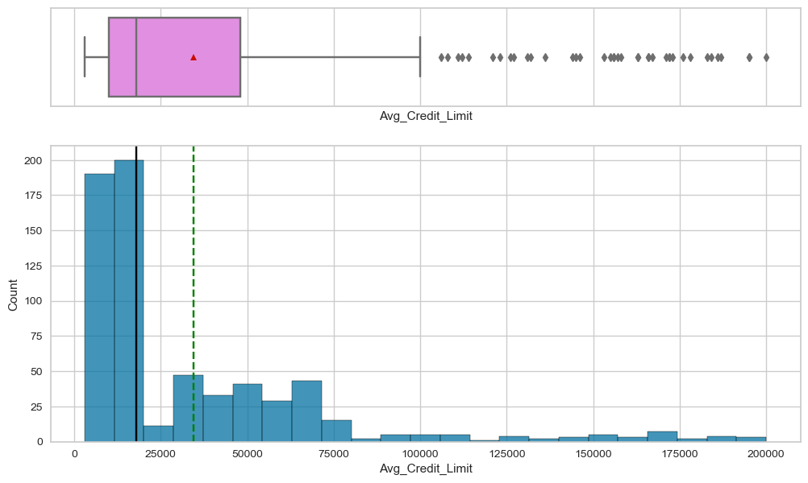

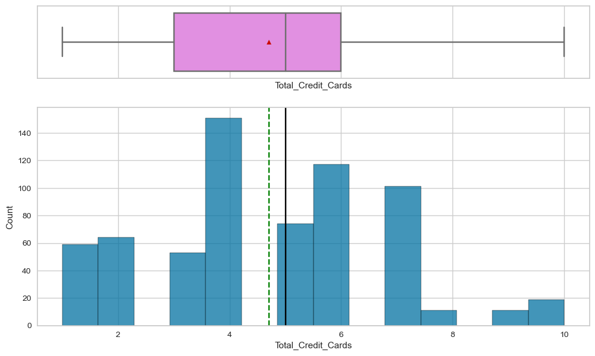

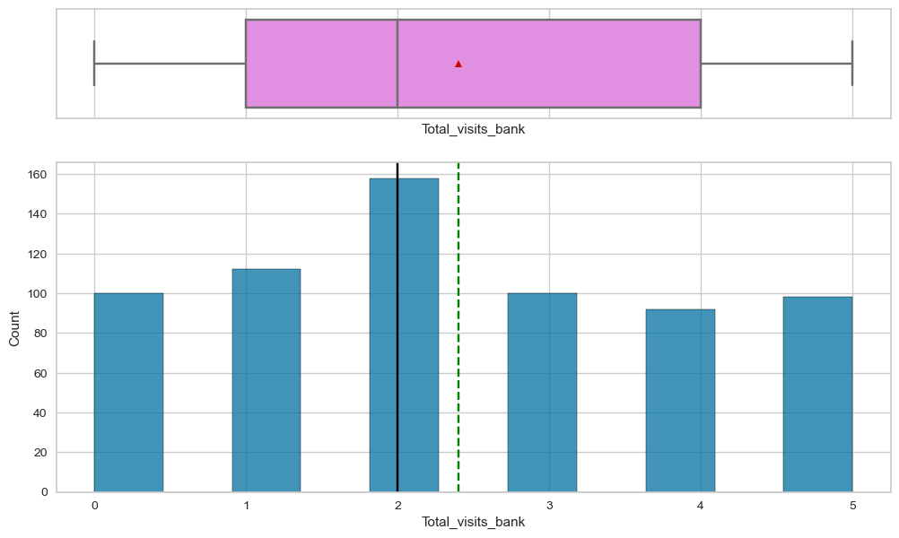

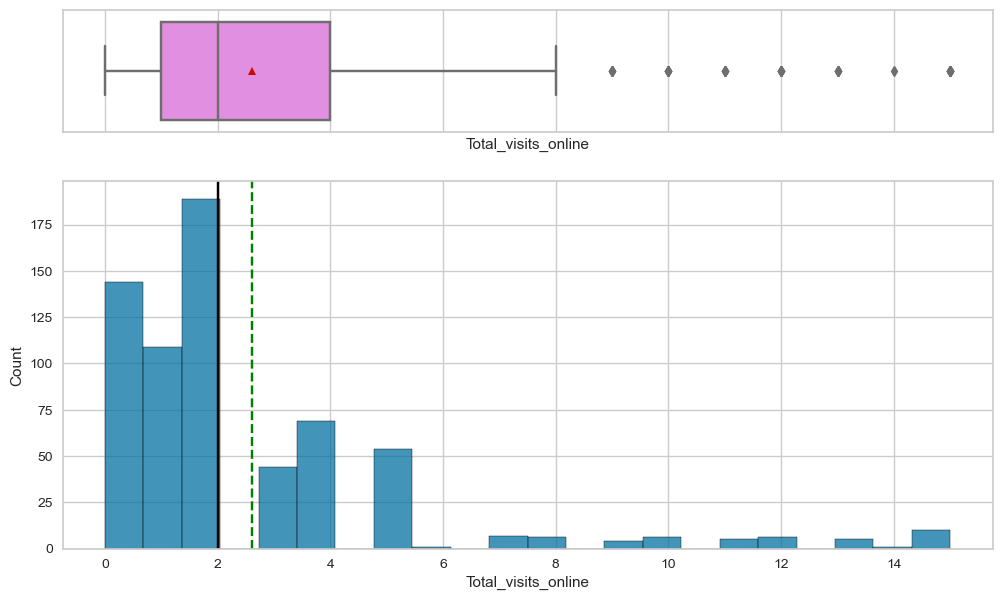

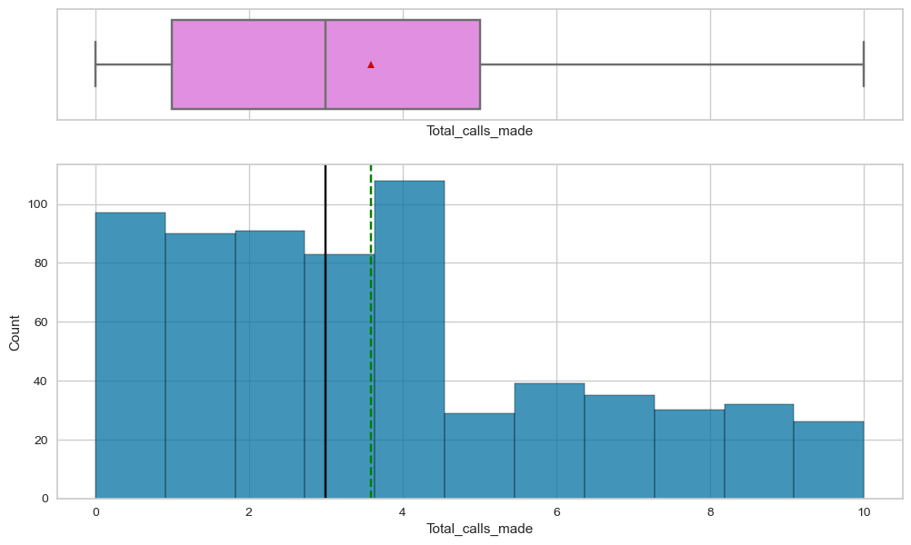

```python
# selecting numerical columns
num_col = data_df.select_dtypes(include=np.number).columns.tolist()

for item in num_col:
    histogram_boxplot(data_df, item)
```

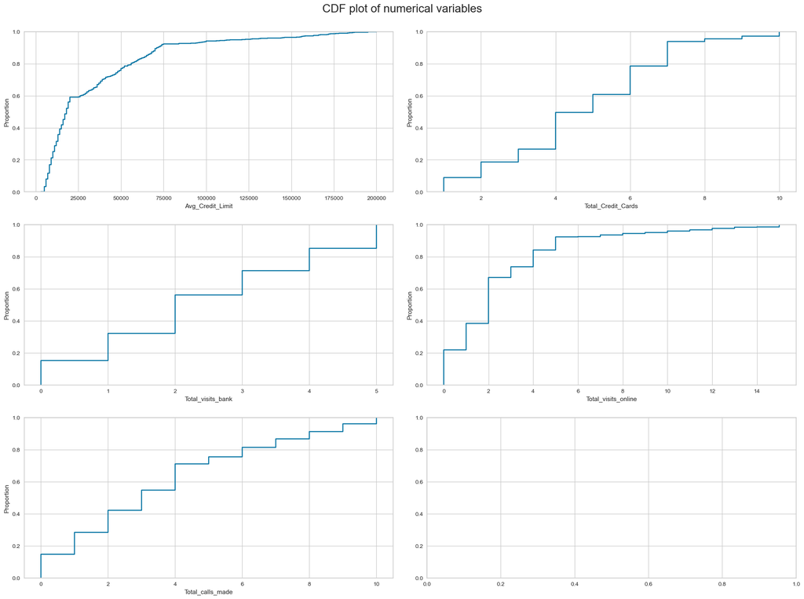

```python
fig, axes = plt.subplots(3, 2, figsize=(20, 15))
fig.suptitle("CDF plot of numerical variables", fontsize=20)
counter = 0
for ii in range(3):
    sns.ecdfplot(ax=axes[ii][0], x=data_df[num_col[counter]])
    counter = counter + 1
    if counter != 5:
        sns.ecdfplot(ax=axes[ii][1], x=data_df[num_col[counter]])
        counter = counter + 1
    else:
        pass

fig.tight_layout(pad=2.0)
```

### Bivariate Analysis

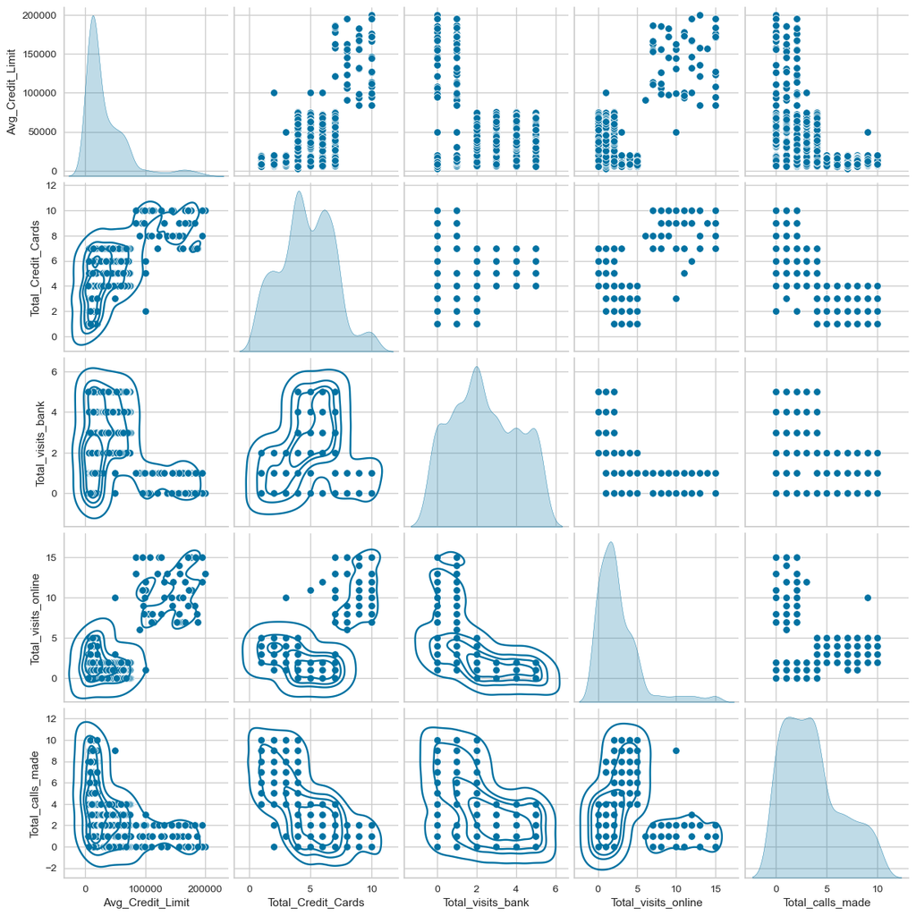

```python
t = sns.pairplot(data_df,diag_kind='kde')
t.map_lower(sns.kdeplot, levels = 5)
```

Through kdeplots, we can observe a few variable pairs to start to form clear clusters. Most notably:

- Unsurprisingly, clients that have lower credit limits have a lower number of credit cards while people with credit limits above 100,000 tend to have the highest number of credit cards
- Furthermore, customers with lower credit limits perform a lower number of online visits
- This also translates to customers that perform online banking the most, consistently have a high number of credit cards
- Clients with the highest online visits (+5) also perform the least amount of calls to the bank

There also seem to be strong correlative relationships between multiple variables can be further explored through correlation heatmap.

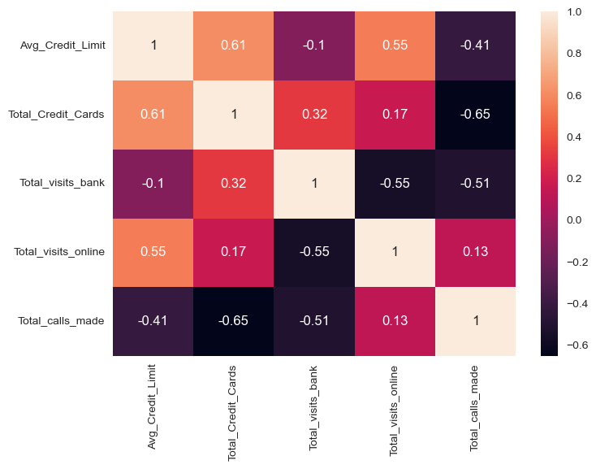

```python
sns.heatmap(data_df.corr(),annot=True)
```

Various important patterns elucidate further here:

- Customers' visits to the bank are inversely proportional to the total visits online. This would suggest that the online/remote banking services are adequate for customers to actually solve their issues. This could also be an indicator of a distinction between tech savvy customer versus not.
- There is also a strong negative correlation between the total number of credit cards and the total number of calls made to the bank. On the other hand, there is a lightly positive correlation between the number of credit cards and bank visits and online visits.
- There is a positive correlation between the average credit limit and visits online, while this postiive correlation is decreased when seen in the context of number of credit cards, despite credit limit and credit card number being highly correlated. This 'discrepancy' would possibly provide insights on the credit size per card between customers performing online banking

To further visualize these relationships it would be advantageous to present the counts (as density) for each othe pairplots.

```python
##To make fair comparisons, the data will be normalized to one, and the pairwise grids divided into 10-by-10 grid. For this stage of EDA, values will be referred to as percentages [0,1]. Z-score scaling was not used since the distribution variances were so different between the variables.

norm_df = pd.DataFrame()
for t in data_df.columns:
    norm_df[t] = preprocessing.minmax_scale(data_df[t])

norm_df.head()
```

|  | Avg_Credit_Limit | Total_Credit_Cards | Total_visits_bank | Total_visits_online | Total_calls_made |
| --- | --- | --- | --- | --- | --- |
| 0 | 0.492386 | 0.111111 | 0.2 | 0.066667 | 0.0 |
| 1 | 0.238579 | 0.222222 | 0.0 | 0.666667 | 0.9 |
| 2 | 0.238579 | 0.666667 | 0.2 | 0.200000 | 0.4 |
| 3 | 0.137056 | 0.444444 | 0.2 | 0.066667 | 0.4 |
| 4 | 0.492386 | 0.555556 | 0.0 | 0.800000 | 0.3 |

```python
def density(df,x,y):
    bins = 10
    H, xedges, yedges = np.histogram2d(df[x],df[y])
    H = H.T
    return H, xedges, yedges

norm_df.columns
```

```
Index(['Avg_Credit_Limit', 'Total_Credit_Cards', 'Total_visits_bank',
       'Total_visits_online', 'Total_calls_made'],
      dtype='object')
```

[output not shown]

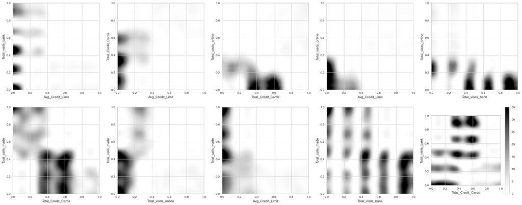

```python
# This needs to be updated for proper labeling

t = norm_df.columns.to_list()
c = list(itertools.combinations(t, 2))
vars = list(set(c))

count = 0
fig = plt.figure(figsize=(30,30))

print(vars)
for y in vars:
    count = count+1
    H, xedges, yedges = density(norm_df,y[0],y[1])
    ax = fig.add_subplot(5,5,count)
    plt.imshow(H, interpolation='sinc', origin='lower', extent=[xedges[0], xedges[-1], yedges[0], yedges[-1]])
    plt.xlabel(y[0])
    plt.ylabel(y[1])

plt.colorbar()
plt.show()
```

So we can see that there are clear gradients in number of clients pertaining to each pair of variables that was not observable for the pairplots. The distribution of credit card number to credit limits seemed to be highly positively correlated. However, we can see that most of the clients are still below the 50% of credit card number have very modest credit limits.

Observations:

## Outlier detection

```
The quantile values for 25, 50 and 75 percentiles respectively for  Avg_Credit_Limit  are given by:
0.25    0.035533
0.50    0.076142
0.75    0.228426
Name: Avg_Credit_Limit, dtype: float64
Resulting in an IQR of: 0.19289340101522842
Leading to the respective lower and upper outer fences of -0.5431472081218274 and 0.8071065989847716
```

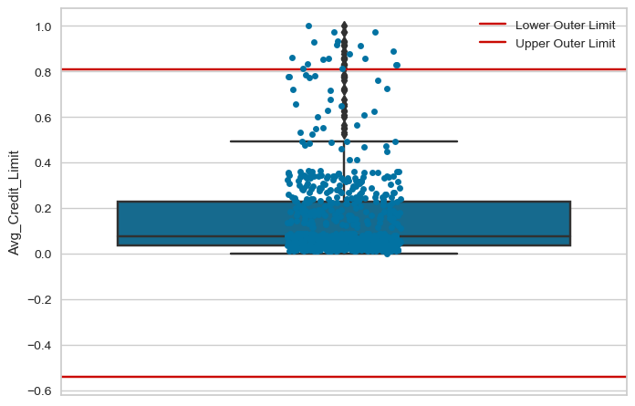

```
The quantile values for 25, 50 and 75 percentiles respectively for  Total_Credit_Cards  are given by:
0.25    0.222222
0.50    0.444444
0.75    0.555556
Name: Total_Credit_Cards, dtype: float64
Resulting in an IQR of: 0.33333333333333337
Leading to the respective lower and upper outer fences of -0.7777777777777778 and 1.5555555555555556
```

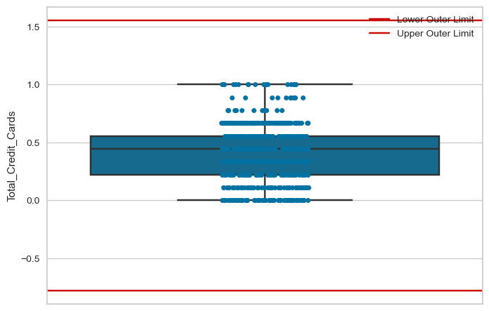

```
The quantile values for 25, 50 and 75 percentiles respectively for  Total_visits_bank  are given by:
0.25    0.2
0.50    0.4
0.75    0.8
Name: Total_visits_bank, dtype: float64
Resulting in an IQR of: 0.6000000000000001
Leading to the respective lower and upper outer fences of -1.6000000000000003 and 2.6000000000000005
```

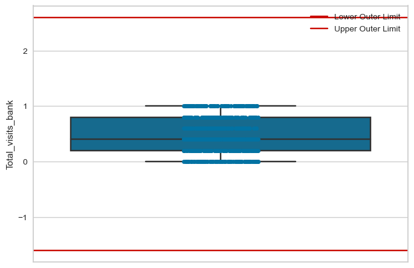

```
The quantile values for 25, 50 and 75 percentiles respectively for  Total_visits_online  are given by:
0.25    0.066667
0.50    0.133333
0.75    0.266667
Name: Total_visits_online, dtype: float64
Resulting in an IQR of: 0.2
Leading to the respective lower and upper outer fences of -0.5333333333333334 and 0.8666666666666667
```

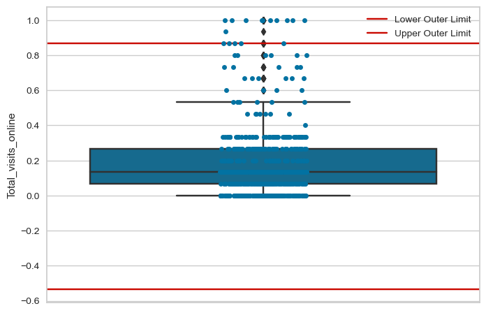

```
The quantile values for 25, 50 and 75 percentiles respectively for  Total_calls_made  are given by:
0.25    0.1
0.50    0.3
0.75    0.5
Name: Total_calls_made, dtype: float64
Resulting in an IQR of: 0.4
Leading to the respective lower and upper outer fences of -1.1 and 1.7000000000000002
```

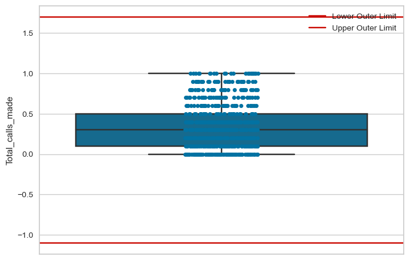

```python
for n in norm_df.columns:
    quantile_data = norm_df[n].quantile([0.25,0.5,0.75])
    IQR = max(quantile_data.values)-min(quantile_data.values)
    low_out = min(quantile_data.values)-3*IQR
    upper_out = max(quantile_data.values)+3*IQR
    print('The quantile values for 25, 50 and 75 percentiles respectively for ',n,' are given by:')
    print(quantile_data)
    print('Resulting in an IQR of: '+str(IQR))
    print('Leading to the respective lower and upper outer fences of '+str(low_out)+' and '+str(upper_out))
    sns.boxplot(y = norm_df[n])
    sns.stripplot(y = norm_df[n])
    plt.axhline(y = low_out, color = 'r', linestyle = '-',label='Lower Outer Limit')
    plt.axhline(y = upper_out, color = 'r', linestyle = '-',label='Upper Outer Limit')
    plt.legend(bbox_to_anchor = (1.0, 1),loc = 'upper right')
    plt.show()
```

## K-means clustering

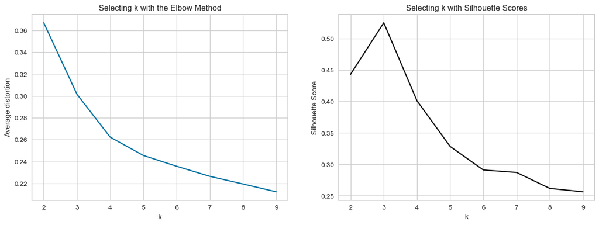

```python
#Finding optimal no. of clusters

clusters=range(2,10)
meanDistortions=[]
silh_scores = []

for k in clusters:
    model=KMeans(n_clusters=k)
    model.fit(norm_df)

    # prediction=model.predict(techSuppScaled)
    c_dist = cdist(norm_df, model.cluster_centers_, 'euclidean')
    minc_dist = np.min(c_dist, axis=1)
    meanDistortions.append(sum(minc_dist) / norm_df.shape[0])

    pred = model.fit_predict(norm_df)
    silh_scores.append(silhouette_score(norm_df, pred))

fig = plt.figure(figsize=(15,5))
fig.add_subplot(121)
plt.plot(clusters, meanDistortions, 'bx-')
plt.xlabel('k')
plt.ylabel('Average distortion')
plt.title('Selecting k with the Elbow Method')

fig.add_subplot(122)
plt.plot(clusters,silh_scores, 'kx-')
plt.xlabel('k')
plt.ylabel('Silhouette Score')
plt.title('Selecting k with Silhouette Scores')
```

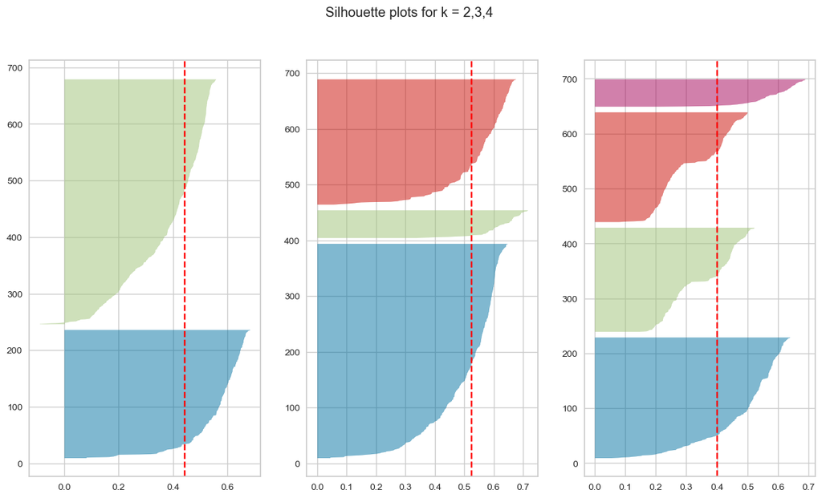

```python
#To account for possible high variability, we can perform Silhouette Plots for the three highest silhouette scores

from yellowbrick.cluster import SilhouetteVisualizer

fig, ax = plt.subplots(1, 3, figsize=(15,8))
for ind,i in enumerate([2,3,4]):
    '''
    Create KMeans instance for different number of clusters
    '''
    km = KMeans(n_clusters=i)
    q, mod = divmod(i, 2)
    '''
    Create SilhouetteVisualizer instance with KMeans instance
    Fit the visualizer
    '''
    visualizer = SilhouetteVisualizer(km, colors='yellowbrick',ax=ax[ind])
    visualizer.fit(norm_df)

    plt.suptitle('Silhouette plots for k = 2,3,4')
```

We see that we maximize cluster separation at n=3, and all clusters are above the mean S.score line. Therefore </b>k=3</b> is the cluster selection for K-Means approach

```python
k_model = KMeans(n_clusters=3)

k_model.fit(norm_df)
prediction=k_model.predict(norm_df)


#Append the prediction
data_df["GROUP"] = prediction
norm_df["GROUP"] = prediction
print("Groups Assigned : \n")
data_df.head()
```

```
Groups Assigned :
```

|  | Avg_Credit_Limit | Total_Credit_Cards | Total_visits_bank | Total_visits_online | Total_calls_made | GROUP |
| --- | --- | --- | --- | --- | --- | --- |
| 0 | 100000 | 2 | 1 | 1 | 0 | 0 |
| 1 | 50000 | 3 | 0 | 10 | 9 | 1 |
| 2 | 50000 | 7 | 1 | 3 | 4 | 0 |
| 3 | 30000 | 5 | 1 | 1 | 4 | 1 |
| 4 | 100000 | 6 | 0 | 12 | 3 | 2 |

```python
data_dfClust = data_df.groupby(['GROUP'])
data_dfClust.mean()
```

| GROUP | Avg_Credit_Limit | Total_Credit_Cards | Total_visits_bank | Total_visits_online | Total_calls_made |
| --- | --- | --- | --- | --- | --- |
| 0 | 33792.207792 | 5.516883 | 3.496104 | 0.981818 | 1.994805 |
| 1 | 12253.333333 | 2.422222 | 0.933333 | 3.542222 | 6.857778 |
| 2 | 141040.000000 | 8.740000 | 0.600000 | 10.900000 | 1.080000 |

```
array([<AxesSubplot: title={'center': 'Avg_Credit_Limit'}, xlabel='[GROUP]'>,
       <AxesSubplot: title={'center': 'Total_Credit_Cards'}, xlabel='[GROUP]'>,
       <AxesSubplot: title={'center': 'Total_calls_made'}, xlabel='[GROUP]'>,
       <AxesSubplot: title={'center': 'Total_visits_bank'}, xlabel='[GROUP]'>,
       <AxesSubplot: title={'center': 'Total_visits_online'}, xlabel='[GROUP]'>],
      dtype=object)
```

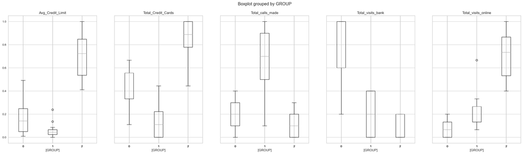

```python
norm_df.boxplot(by='GROUP', layout = (1,5),figsize=(30,8))
```

[figure not shown]

```python
fig, axes = plt.subplots(1, 5, figsize=(30, 8))
fig.suptitle("Boxplot of original numerical variables for each K-Means cluster", fontsize=20)
counter = 0
for ind,i in enumerate(data_df.columns[ : -1]):
    sns.boxplot(ax=axes[ind], y=data_df[i], x=data_df["GROUP"])
    counter = counter + 1
```

## Customer Profiling

# Hierarchical Clustering

#### Comparing distance metrics across the general linkage methods

```python
# list of distance metrics
distance_metrics = ["euclidean", "chebyshev", "mahalanobis", "cityblock"]

# list of linkage methods
linkage_methods = ["single", "complete", "average", "weighted"]

high_cophenet_corr = 0
high_dm_lm = [0, 0]

for dm in distance_metrics:
    for lm in linkage_methods:
        Z = linkage(norm_df, metric=dm, method=lm)
        c, coph_dists = cophenet(Z, pdist(norm_df))
        print(
            "Cophenetic correlation for {} distance and {} linkage is {}.".format(
                dm.capitalize(), lm, c
            )
        )
        if high_cophenet_corr < c:
            high_cophenet_corr = c
            high_dm_lm[0] = dm
            high_dm_lm[1] = lm
    print()
```

```
Cophenetic correlation for Euclidean distance and single linkage is 0.9236946931663347.
Cophenetic correlation for Euclidean distance and complete linkage is 0.9437404861259896.
Cophenetic correlation for Euclidean distance and average linkage is 0.9583680719018867.
Cophenetic correlation for Euclidean distance and weighted linkage is 0.9560332525799654.

Cophenetic correlation for Chebyshev distance and single linkage is 0.8831738740524897.
Cophenetic correlation for Chebyshev distance and complete linkage is 0.8861269735013526.
Cophenetic correlation for Chebyshev distance and average linkage is 0.9563044516288861.
Cophenetic correlation for Chebyshev distance and weighted linkage is 0.9379490695351493.

Cophenetic correlation for Mahalanobis distance and single linkage is 0.9179607488899991.
Cophenetic correlation for Mahalanobis distance and complete linkage is 0.6323100106939284.
Cophenetic correlation for Mahalanobis distance and average linkage is 0.8273830962851954.
Cophenetic correlation for Mahalanobis distance and weighted linkage is 0.768545181927562.

Cophenetic correlation for Cityblock distance and single linkage is 0.9446920921208822.
Cophenetic correlation for Cityblock distance and complete linkage is 0.9493400032728226.
Cophenetic correlation for Cityblock distance and average linkage is 0.9583660449186626.
Cophenetic correlation for Cityblock distance and weighted linkage is 0.9478856067174707.
```

```python
# printing the combination of distance metric and linkage method with the highest cophenetic correlation
print(
    "Highest cophenetic correlation is {}, which is obtained with {} distance and {} linkage.".format(
        high_cophenet_corr, high_dm_lm[0].capitalize(), high_dm_lm[1]
    )
)
```

```
Highest cophenetic correlation is 0.9583680719018867, which is obtained with Euclidean distance and average linkage.
```

- We see that Euclidean and Cityblock distances give the best cophenetic correlation values across linkage methods

```python
# list of linkage methods
linkage_methods = ["single", "complete", "average", "centroid", "ward", "weighted"]

high_cophenet_corr = 0
high_dm_lm = [0, 0]

for lm in linkage_methods:
    Z = linkage(norm_df, metric="euclidean", method=lm)
    c, coph_dists = cophenet(Z, pdist(norm_df))
    print("Cophenetic correlation for {} linkage is {}.".format(lm, c))
    if high_cophenet_corr < c:
        high_cophenet_corr = c
        high_dm_lm[0] = "euclidean"
        high_dm_lm[1] = lm
```

```
Cophenetic correlation for single linkage is 0.9236946931663347.
Cophenetic correlation for complete linkage is 0.9437404861259896.
Cophenetic correlation for average linkage is 0.9583680719018867.
Cophenetic correlation for centroid linkage is 0.9568387285910476.
Cophenetic correlation for ward linkage is 0.8562148287975094.
Cophenetic correlation for weighted linkage is 0.9560332525799654.
```

```python
# printing the combination of distance metric and linkage method with the highest cophenetic correlation
print(
    "Highest cophenetic correlation is {}, which is obtained with {} linkage.".format(
        high_cophenet_corr, high_dm_lm[1]
    )
)
```

```
Highest cophenetic correlation is 0.9583680719018867, which is obtained with average linkage.
```

- Comparing dendrograms between linkage methods

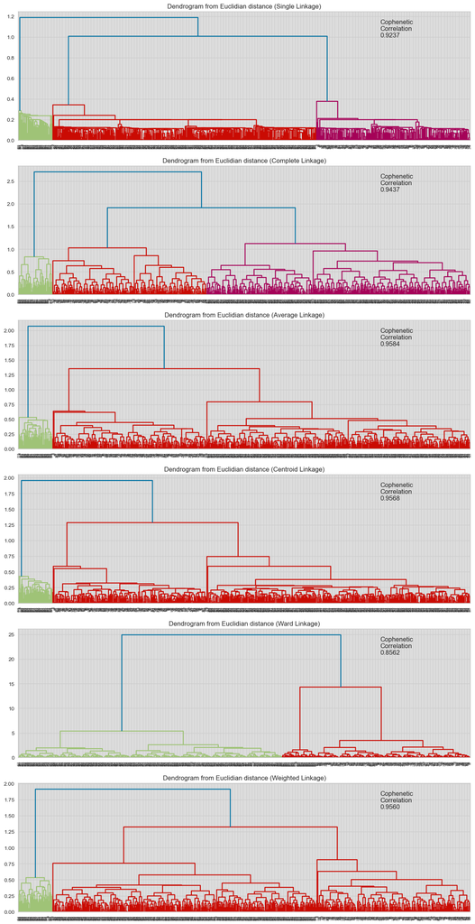

```python
# list of linkage methods
linkage_methods = ["single", "complete", "average", "centroid", "ward", "weighted"]

# lists to save results of cophenetic correlation calculation
compare_cols = ["Linkage", "Cophenetic Coefficient"]
compare = []

# to create a subplot image
fig, axs = plt.subplots(len(linkage_methods), 1, figsize=(15, 30))

# We will enumerate through the list of linkage methods above
# For each linkage method, we will plot the dendrogram and calculate the cophenetic correlation
for i, method in enumerate(linkage_methods):
    Z = linkage(norm_df, metric="euclidean", method=method)

    dendrogram(Z, ax=axs[i])
    axs[i].set_title(f"Dendrogram from Euclidian distance ({method.capitalize()} Linkage)")

    coph_corr, coph_dist = cophenet(Z, pdist(norm_df))

    axs[i].annotate(
        f"Cophenetic\nCorrelation\n{coph_corr:0.4f}",
        (0.80, 0.80),
        xycoords="axes fraction",
    )

    compare.append([method, coph_corr])
```

Given that Cityblock also gave really high Cophenetic values, we should also observe the resulting dendrograms.

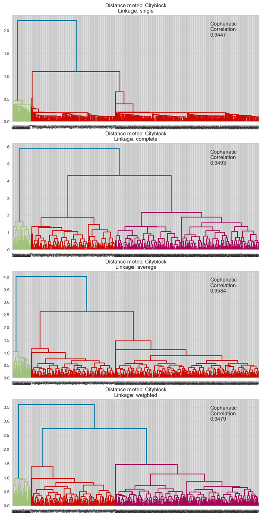

```python
dm = 'cityblock'

# list of linkage methods
linkage_methods = ["single", "complete", "average", "weighted"]

# to create a subplot image
fig, axs = plt.subplots( len(linkage_methods), 1, figsize=(10, 20) )

i = 0

for lm in linkage_methods:
    Z = linkage(norm_df, metric=dm, method=lm)

    dendrogram(Z, ax=axs[i])
    axs[i].set_title("Distance metric: {}\nLinkage: {}".format(dm.capitalize(), lm))

    coph_corr, coph_dist = cophenet(Z, pdist(norm_df))
    axs[i].annotate(
        f"Cophenetic\nCorrelation\n{coph_corr:0.4f}",
        (0.80, 0.80),
        xycoords="axes fraction",
    )
    i += 1
```

We can also observe the two linkage methods within the Chebyshev distance metric that resulted in cophenetic values above 0.9.

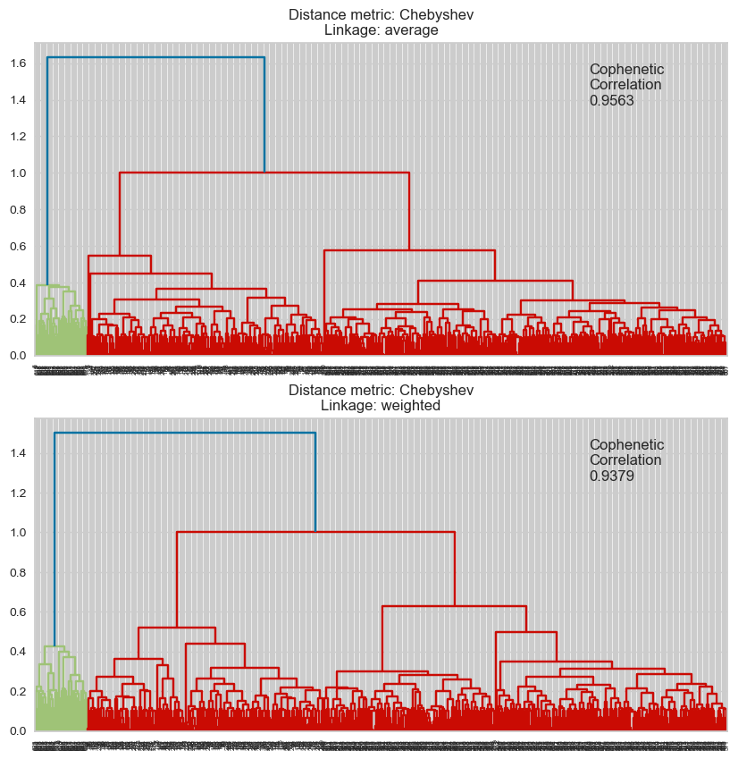

```python
dm = 'chebyshev'

# list of linkage methods
linkage_methods = ["average", "weighted"]

# to create a subplot image
fig, axs = plt.subplots( len(linkage_methods), 1, figsize=(10, 10) )

i = 0

for lm in linkage_methods:
    Z = linkage(norm_df, metric=dm, method=lm)

    dendrogram(Z, ax=axs[i])
    axs[i].set_title("Distance metric: {}\nLinkage: {}".format(dm.capitalize(), lm))

    coph_corr, coph_dist = cophenet(Z, pdist(norm_df))
    axs[i].annotate(
        f"Cophenetic\nCorrelation\n{coph_corr:0.4f}",
        (0.80, 0.80),
        xycoords="axes fraction",
    )
    i += 1
```

Various dendograms have effectively split the data into clusters. The Cityblock distance method using the Complete linkage achieved the highest drop (>2) between the resulting three clusters with a high cophenetic correlation value of ~0.95.

```python
HCmodel = AgglomerativeClustering(n_clusters=3, affinity="cityblock", linkage="complete")
HCmodel.fit(norm_df)

norm_df["HC_GROUP"] = HCmodel.labels_
data_df["HC_GROUP"] = HCmodel.labels_

#Append the prediction
print("Groups Assigned : \n")
data_df.head()
```

```
Groups Assigned :
```

|  | Avg_Credit_Limit | Total_Credit_Cards | Total_visits_bank | Total_visits_online | Total_calls_made | GROUP | HC_GROUP |
| --- | --- | --- | --- | --- | --- | --- | --- |
| 0 | 100000 | 2 | 1 | 1 | 0 | 0 | 0 |
| 1 | 50000 | 3 | 0 | 10 | 9 | 1 | 2 |
| 2 | 50000 | 7 | 1 | 3 | 4 | 0 | 0 |
| 3 | 30000 | 5 | 1 | 1 | 4 | 1 | 2 |
| 4 | 100000 | 6 | 0 | 12 | 3 | 2 | 1 |

```python
data_dfClust = data_df.groupby(['HC_GROUP'])
data_dfClust.mean()
```

| HC_GROUP | Avg_Credit_Limit | Total_Credit_Cards | Total_visits_bank | Total_visits_online | Total_calls_made | GROUP |
| --- | --- | --- | --- | --- | --- | --- |
| 0 | 33792.207792 | 5.516883 | 3.496104 | 0.981818 | 1.994805 | 0.0 |
| 1 | 141040.000000 | 8.740000 | 0.600000 | 10.900000 | 1.080000 | 2.0 |
| 2 | 12253.333333 | 2.422222 | 0.933333 | 3.542222 | 6.857778 | 1.0 |

```
array([<AxesSubplot: title={'center': 'Avg_Credit_Limit'}, xlabel='[HC_GROUP]'>,
       <AxesSubplot: title={'center': 'Total_Credit_Cards'}, xlabel='[HC_GROUP]'>,
       <AxesSubplot: title={'center': 'Total_calls_made'}, xlabel='[HC_GROUP]'>,
       <AxesSubplot: title={'center': 'Total_visits_bank'}, xlabel='[HC_GROUP]'>,
       <AxesSubplot: title={'center': 'Total_visits_online'}, xlabel='[HC_GROUP]'>],
      dtype=object)
```

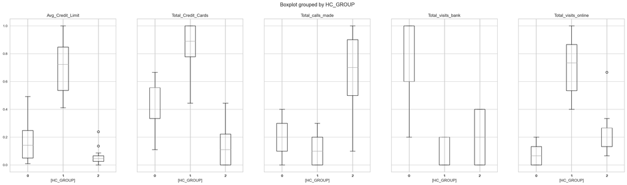

```python
norm_df.drop(columns=['GROUP']).boxplot(by='HC_GROUP', layout = (1,5),figsize=(30,8))
```

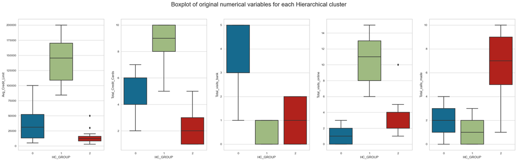

```python
fig, axes = plt.subplots(1, 5, figsize=(30, 8))
fig.suptitle("Boxplot of original numerical variables for each Hierarchical cluster", fontsize=20)
counter = 0
for ind,i in enumerate(data_df.drop(columns=['GROUP']).columns[ : -1]):
    sns.boxplot(ax=axes[ind], y=data_df[i], x=data_df["HC_GROUP"])
    counter = counter + 1
```

```python
print('The percentage of customers for each base are: ')
100*norm_df['HC_GROUP'].value_counts()/len(norm_df)
```

```
The percentage of customers for each base are:
```

```
0    58.333333
2    34.090909
1     7.575758
Name: HC_GROUP, dtype: float64
```

## Customer Profiling

We can see that these clusters match the observations made with K-Means clustering approach.

## K-Means vs Hierarchical Clustering

By grouping variables by the Hierarchical Clusters (while including GROUP variable from the K-Means Clustering) we observe that there was no difference in the assignment of clustering grouping between the two methods, since the mean values of variable GROUP are integers. I.e.:

- K-means group 1 pertains to HCluster group 1
- K-means group 2 pertains to HCluster group 3
- K-means group 3 pertains to HCluster group 2

## Actionable insights and recommendations:

- Most of their clientele has credit limit is skewed below the 10% percentile of the consumer base.
  - Therefore, I would recommend special attention being given to clients with low credit limits (especially in the median range of number of credit cards held). These clients likely pertain to consumers starting to increase their credit score. Instituting features online to handle many cards and how to combine them to facilitate credit building could be very advantageous.
- Most customers are not really taking advantage of the online banking
  - The ones that are, are people with high credit limits (likely high credit scores in response) and the highest number of credit cards. Online ads should be carefully selected as this cluster would be business and financially savvy. However, this would be the main point of contact for this cluster.
- Customers that frequent going to the bank would rather call than visit online.
  - With the exception of people who call frequently, or frequently go to the bank
  - This cluster should be a large focus of the bank as their credit limits are higher, they purchase >2-fold more credit products from the bank and they are the largest percentage of the customer base
  - Given that average CC holders rather go to the bank than call, despite being such a large percentage of the customer base, the business either should really pay attention to updating their online banking features to better cater to the goals of this group.
    - While having the second largest number of credit cards and credit limit, they make up +58% of customers meaning that they are the largest source of revenue
    - By making online banking more accessible to this group, the business would facilitate accessing their client base through promotions. As of now, their biggest group would mainly hear about new offers through physical visits to the bank.
    - Another way of going about this, is making the personal touch much more accessible (would likely be more expensive than updating online features)